# Module 4: Data Wrangling I

PUBHLT0411: Statistical Packages for Public Health Data Analysis

Rebecca Deek, PhD

University of Pittsburgh, Biostatistics and Health Data Science

## Housekeeping/setup

```r
# the code below will load the necessary packages for this assignment
# packages are normally loaded using library(packageName) after installing them.
# the `pacman` package has a function called `p_load` that checks if a package is installed.
# if it isn't installed, it will install it, otherwise it will load it.

# this line installs the pacman package, if you need it
if(!require(pacman)){
  install.packages(pacman)
  library(pacman)
}

pacman::p_load(countdown)
pacman::p_load(MASS)
pacman::p_load(tidyverse)
pacman::p_load(janitor)

# data setup
data(birthwt)
```

## Data manipulation with `dplyr`

- `dplyr` is a `tidyverse` package the provides functions for the grammar of data manipulation.
  - `select` relevant variables.
  - `filter` observations to samples of interest.
  - `mutate` new variables that are functions of existing ones.
  - `summarise` data points.
  - `rename` variables.
  - `arrange` observations or `relocate` variables into a more manageable or intuitive format.

## `dplyr` basics

- Each function (“verb”) is designed to do one action and do it well.
  - Gives rise to a modular structure that combines functions easily.
    - Yay for piping (`%>%` and `|>`)!!
- Although each function has a specific task, they share a common structure:
  - The first argument is always a data frame.
  - The subsequent arguments typically describe which columns to operate on using the variable names (without quotes).
  - The output is always a new data frame.

```r
data_clean = dplyr::verb(.data = df, ... = doSomeDataManipulation)
```

## `dplyr` and masking

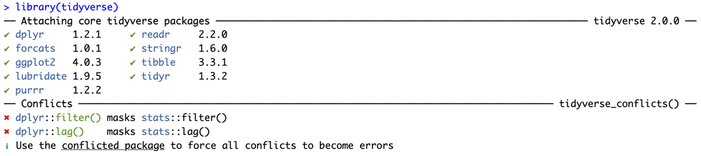

- `R` lets us know that there are conflicts between packages.
- In this case, between `dplyr` and other loaded packages.
- Since dplyr was loaded last it “masks” the functions with the same name from other packages
  - To used the `filter` function from the `stats` package you’ll need to use the full name `stats::filter`.
  - `packagename::function` syntax is always available and precise!

## Aside: Tibbles

- A core component of the tidyverse is the `tibble` package, which extends data frames to be more modern.
- Tibbles *are* data.frames.
  - But they have nicer a printing method and are “lazy” and “surly”.

```r
head(birthwt)
```

```
   low age lwt race smoke ptl ht ui ftv  bwt
85   0  19 182    2     0   0  0  1   0 2523
86   0  33 155    3     0   0  0  0   3 2551
87   0  20 105    1     1   0  0  0   1 2557
88   0  21 108    1     1   0  0  1   2 2594
89   0  18 107    1     1   0  0  1   0 2600
91   0  21 124    3     0   0  0  0   0 2622
```

```r
birthwt = tibble::as_tibble(birthwt)
birthwt
```

```
# A tibble: 189 × 10
     low   age   lwt  race smoke   ptl    ht    ui   ftv   bwt
   <int> <int> <int> <int> <int> <int> <int> <int> <int> <int>
 1     0    19   182     2     0     0     0     1     0  2523
 2     0    33   155     3     0     0     0     0     3  2551
 3     0    20   105     1     1     0     0     0     1  2557
 4     0    21   108     1     1     0     0     1     2  2594
 5     0    18   107     1     1     0     0     1     0  2600
 6     0    21   124     3     0     0     0     0     0  2622
 7     0    22   118     1     0     0     0     0     1  2637
 8     0    17   103     3     0     0     0     0     1  2637
 9     0    29   123     1     1     0     0     0     1  2663
10     0    26   113     1     1     0     0     0     0  2665
# ℹ 179 more rows
```

## Pipes

> In software engineering, a pipeline consists of a chain of processing elements, arranged so that the output of each element is the input of the next. *Wikipedia*

[figure not shown]

## Magrittr and native pipes

- Pipes were first introduced into R in 2014 as `%>%` via the `magrittr` [package](https://magrittr.tidyverse.org/).
  - Part of `tidyverse` ecosystem.
- The native pipe `|>` was introduced in 2021 and updated in 2023.
  - Does not require any package to be loaded to use.
- The keyboard shortcuts:
  - Shift + Command + M (Mac)
  - Shift + Ctrl + M (Windows)
  - Default is `magrittr` pipe but this can be changed in settings, if desired.

The follow lines of code are equivalent.

```r
f(x)
mean(x)
```

```r
x |> f()
x |> mean()
```

```r
x %>% f()
x %>% mean()
```

## Readability of pipes

Pipes make your code more readable by:

- Avoiding nested function calls.

```r
work_RAD = do_science(do_lecture(commute(morning_RAD)))
```

- Minimizing the need for local variables and function definitions.

```r
commuter_RAD = commute(morning_RAD)
lecture_RAD = do_lecture(commuter_RAD)
research_RAD = do_science(teacher_RAD)
```

- Structuring sequences of data operations left-to-right (as opposed to from the inside and out).

```r
work_RAD = morning_RAD |>
  commute() |>
  do_lecture() |>
  do_science()
```

- Making it easy to add steps anywhere in the sequence of operations.

```r
work_RAD = morning_RAD |>
  commute() |>
  do_lecture() |>
  eat_lunch() |>
  do_science()
```

## More about pipes

- `|>` can be read as “and then”.
- Deciding between the two pipes is a personal preference (or could just not pipe).
  - Can mostly be used interchangeably.
  - Native pipe requires >= R v4.1
- Typically, the output of the prior line is passed as the first argument of the next line.
  - You can specify the use of a different argument with `.` for `%>%` or `_` for `|>`.

```r
birthwt %>% boxplot(bwt ~ race, data = .)
birthwt |> boxplot(bwt ~ race, data = _)
```

## Common row-wise functions

- `filter()`: pick rows based on logical conditions.
- `slice()`: pick rows based on positional index.
- `arrange()`: sort/reorder rows based on variable(s).
- `distinct()`: filter for unique rows.
- `group_by()`/`ungroup()`: modifying verb (tbl $\leftrightarrow$ grouped tbl) for subsequent verbs to act upon.
- `summarise()`/`count()`: creates new tbl by collapsing multiple rows into summary.
- … many others!

## `filter()`

- Keeps or removes rows based on the values of column(s) [variable(s)].
- Takes a data frame as input. Second and subsequent arguments are conditions that must be true to keep the row.

```r
dplyr::filter(birthwt, age > 25)
```

```
# A tibble: 54 × 10
     low   age   lwt  race smoke   ptl    ht    ui   ftv   bwt
   <int> <int> <int> <int> <int> <int> <int> <int> <int> <int>
 1     0    33   155     3     0     0     0     0     3  2551
 2     0    29   123     1     1     0     0     0     1  2663
 3     0    26   113     1     1     0     0     0     0  2665
 4     0    30   107     3     0     1     0     1     2  2750
 5     0    28   120     1     1     0     0     0     1  2821
 6     0    32   121     3     0     0     0     0     2  2835
 7     0    31   100     1     0     0     0     1     3  2835
 8     0    36   202     1     0     0     0     0     1  2836
 9     0    28   120     3     0     0     0     0     0  2863
10     0    28   167     1     0     0     0     0     0  2877
# ℹ 44 more rows
```

## `filter()`

- Available logical operators: `>` (greater than), `>=` (greater than or equal to), `<` (less than), `<=` (less than or equal to), `==` (equal to), and `!=` (not equal to).
- Conditions with `&` or `,` indicate “and” statements (check for both conditions). Conditions with `|` indicate “or” statements (check for either condition).

```r
# keep between age 25 (exclusive) and 30 (inclusive)
birthwt |> dplyr::filter(age > 25 & age <= 30)
```

```
# A tibble: 34 × 10
     low   age   lwt  race smoke   ptl    ht    ui   ftv   bwt
   <int> <int> <int> <int> <int> <int> <int> <int> <int> <int>
 1     0    29   123     1     1     0     0     0     1  2663
 2     0    26   113     1     1     0     0     0     0  2665
 3     0    30   107     3     0     1     0     1     2  2750
 4     0    28   120     1     1     0     0     0     1  2821
 5     0    28   120     3     0     0     0     0     0  2863
 6     0    28   167     1     0     0     0     0     0  2877
 7     0    29   150     1     0     0     0     0     2  2920
 8     0    26   168     2     1     0     0     0     0  2920
 9     0    29   140     1     1     0     0     0     2  2977
10     0    27   124     1     1     0     0     0     0  2922
# ℹ 24 more rows
```

```r
# keep older than 25 with history of hypertension and save as new object
birthwt.over25.ht = birthwt |> dplyr::filter(age > 25, ht == 1)
birthwt.over25.ht
```

```
# A tibble: 2 × 10
    low   age   lwt  race smoke   ptl    ht    ui   ftv   bwt
  <int> <int> <int> <int> <int> <int> <int> <int> <int> <int>
1     1    34   187     2     1     0     1     0     0  1135
2     1    26   154     3     0     1     1     0     1  2442
```

## `filter()`

- `&` and `|` statements need to be in logical for every condition (i.e no `var == 1 | 2`).

```r
birthwt |> dplyr::filter(ftv == 2 | ftv == 3 | ftv == 4)
```

```
# A tibble: 41 × 10
     low   age   lwt  race smoke   ptl    ht    ui   ftv   bwt
   <int> <int> <int> <int> <int> <int> <int> <int> <int> <int>
 1     0    33   155     3     0     0     0     0     3  2551
 2     0    21   108     1     1     0     0     1     2  2594
 3     0    30   107     3     0     1     0     1     2  2750
 4     0    25   118     1     1     0     0     0     3  2782
 5     0    32   121     3     0     0     0     0     2  2835
 6     0    31   100     1     0     0     0     1     3  2835
 7     0    25   120     3     0     0     0     1     2  2877
 8     0    29   150     1     0     0     0     0     2  2920
 9     0    29   140     1     1     0     0     0     2  2977
10     0    19   138     1     1     0     0     0     2  2977
# ℹ 31 more rows
```

- `%in%` is a shortcut for combining `==` and `|` when using the same variable.

```r
birthwt |> dplyr::filter(ftv %in% c(2, 3, 4))
```

```
# A tibble: 41 × 10
     low   age   lwt  race smoke   ptl    ht    ui   ftv   bwt
   <int> <int> <int> <int> <int> <int> <int> <int> <int> <int>
 1     0    33   155     3     0     0     0     0     3  2551
 2     0    21   108     1     1     0     0     1     2  2594
 3     0    30   107     3     0     1     0     1     2  2750
 4     0    25   118     1     1     0     0     0     3  2782
 5     0    32   121     3     0     0     0     0     2  2835
 6     0    31   100     1     0     0     0     1     3  2835
 7     0    25   120     3     0     0     0     1     2  2877
 8     0    29   150     1     0     0     0     0     2  2920
 9     0    29   140     1     1     0     0     0     2  2977
10     0    19   138     1     1     0     0     0     2  2977
# ℹ 31 more rows
```

## `filter()`

- So far the syntax has been selecting rows to keep, can also provide which rows to drop.

```r
birthwt |> dplyr::filter(ftv != 0 & ftv != 1)
```

```
# A tibble: 42 × 10
     low   age   lwt  race smoke   ptl    ht    ui   ftv   bwt
   <int> <int> <int> <int> <int> <int> <int> <int> <int> <int>
 1     0    33   155     3     0     0     0     0     3  2551
 2     0    21   108     1     1     0     0     1     2  2594
 3     0    30   107     3     0     1     0     1     2  2750
 4     0    25   118     1     1     0     0     0     3  2782
 5     0    32   121     3     0     0     0     0     2  2835
 6     0    31   100     1     0     0     0     1     3  2835
 7     0    25   120     3     0     0     0     1     2  2877
 8     0    29   150     1     0     0     0     0     2  2920
 9     0    29   140     1     1     0     0     0     2  2977
10     0    19   138     1     1     0     0     0     2  2977
# ℹ 32 more rows
```

- Notice that `!` + `%in%` is equivalent to a drop statement with `&`.

```r
birthwt |> dplyr::filter(!(ftv %in% c(0, 1)))
```

```
# A tibble: 42 × 10
     low   age   lwt  race smoke   ptl    ht    ui   ftv   bwt
   <int> <int> <int> <int> <int> <int> <int> <int> <int> <int>
 1     0    33   155     3     0     0     0     0     3  2551
 2     0    21   108     1     1     0     0     1     2  2594
 3     0    30   107     3     0     1     0     1     2  2750
 4     0    25   118     1     1     0     0     0     3  2782
 5     0    32   121     3     0     0     0     0     2  2835
 6     0    31   100     1     0     0     0     1     3  2835
 7     0    25   120     3     0     0     0     1     2  2877
 8     0    29   150     1     0     0     0     0     2  2920
 9     0    29   140     1     1     0     0     0     2  2977
10     0    19   138     1     1     0     0     0     2  2977
# ℹ 32 more rows
```

## `slice()`

- Extracts rows using integer location.
- Input is a data frame and a positional index (default).

```r
# select rows 7 through 10
birthwt |> dplyr::slice(7:10)
```

```
# A tibble: 4 × 10
    low   age   lwt  race smoke   ptl    ht    ui   ftv   bwt
  <int> <int> <int> <int> <int> <int> <int> <int> <int> <int>
1     0    22   118     1     0     0     0     0     1  2637
2     0    17   103     3     0     0     0     0     1  2637
3     0    29   123     1     1     0     0     0     1  2663
4     0    26   113     1     1     0     0     0     0  2665
```

```r
# select the first two rows
birthwt |> dplyr::slice_head(n = 2)
```

```
# A tibble: 2 × 10
    low   age   lwt  race smoke   ptl    ht    ui   ftv   bwt
  <int> <int> <int> <int> <int> <int> <int> <int> <int> <int>
1     0    19   182     2     0     0     0     1     0  2523
2     0    33   155     3     0     0     0     0     3  2551
```

```r
# select the last 2% of rows
birthwt |> dplyr::slice_tail(prop = 0.02)
```

```
# A tibble: 3 × 10
    low   age   lwt  race smoke   ptl    ht    ui   ftv   bwt
  <int> <int> <int> <int> <int> <int> <int> <int> <int> <int>
1     1    23    94     3     1     0     0     0     0  2495
2     1    17   142     2     0     0     1     0     0  2495
3     1    21   130     1     1     0     1     0     3  2495
```

## `slice()`

- `slice_min` and `slice_max` select the rows with the smallest or largest values of a variable.

```r
# select the first row with the smallest age
birthwt |> dplyr::slice_min(age, n = 1)
```

```
# A tibble: 3 × 10
    low   age   lwt  race smoke   ptl    ht    ui   ftv   bwt
  <int> <int> <int> <int> <int> <int> <int> <int> <int> <int>
1     0    14   135     1     0     0     0     0     0  3941
2     1    14   101     3     1     1     0     0     0  2466
3     1    14   100     3     0     0     0     0     2  2495
```

```r
# select the last row with the largest birthweight
birthwt |> dplyr::slice_max(bwt, n = 1)
```

```
# A tibble: 1 × 10
    low   age   lwt  race smoke   ptl    ht    ui   ftv   bwt
  <int> <int> <int> <int> <int> <int> <int> <int> <int> <int>
1     0    45   123     1     0     0     0     0     1  4990
```

## `arrange()`

- Changes the order of the rows based on the value of column(s).
- Input is a data frame and a set of column names to order by.
- Each additional column will be used to break ties in the values of the preceding columns.

```r
birthwt |> dplyr::arrange(age, bwt)
```

```
# A tibble: 189 × 10
     low   age   lwt  race smoke   ptl    ht    ui   ftv   bwt
   <int> <int> <int> <int> <int> <int> <int> <int> <int> <int>
 1     1    14   101     3     1     1     0     0     0  2466
 2     1    14   100     3     0     0     0     0     2  2495
 3     0    14   135     1     0     0     0     0     0  3941
 4     1    15   110     1     0     0     0     0     0  2353
 5     1    15   115     3     0     0     0     1     0  2381
 6     0    15    98     2     0     0     0     0     0  2778
 7     1    16   130     3     0     0     0     0     1  1899
 8     0    16   110     3     0     0     0     0     0  3175
 9     0    16   112     2     0     0     0     0     0  3374
10     0    16   135     1     1     0     0     0     0  3374
# ℹ 179 more rows
```

## `arrange()`

- `desc()` can be used on a column inside of `arrange()`.
  - Reorders the rows based on that column in descending (big-to-small) order.

```r
birthwt |> dplyr::arrange(desc(age))
```

```
# A tibble: 189 × 10
     low   age   lwt  race smoke   ptl    ht    ui   ftv   bwt
   <int> <int> <int> <int> <int> <int> <int> <int> <int> <int>
 1     0    45   123     1     0     0     0     0     1  4990
 2     0    36   202     1     0     0     0     0     1  2836
 3     0    36   175     1     0     0     0     0     0  3600
 4     0    35   121     2     1     1     0     0     1  2948
 5     0    35   170     1     0     1     0     0     1  4174
 6     1    34   187     2     1     0     1     0     0  1135
 7     0    33   155     3     0     0     0     0     3  2551
 8     0    33   109     1     1     0     0     0     1  3033
 9     0    33   117     1     0     0     0     1     1  3912
10     0    32   121     3     0     0     0     0     2  2835
# ℹ 179 more rows
```

Remember the number of rows has not changed. We’re only *arranging* the data, we’re **not** filtering it.

## `distinct()`

- Finds all the unique rows in a dataset.

```r
birthwt |> dplyr::distinct()
```

```
# A tibble: 184 × 10
     low   age   lwt  race smoke   ptl    ht    ui   ftv   bwt
   <int> <int> <int> <int> <int> <int> <int> <int> <int> <int>
 1     0    19   182     2     0     0     0     1     0  2523
 2     0    33   155     3     0     0     0     0     3  2551
 3     0    20   105     1     1     0     0     0     1  2557
 4     0    21   108     1     1     0     0     1     2  2594
 5     0    18   107     1     1     0     0     1     0  2600
 6     0    21   124     3     0     0     0     0     0  2622
 7     0    22   118     1     0     0     0     0     1  2637
 8     0    17   103     3     0     0     0     0     1  2637
 9     0    29   123     1     1     0     0     0     1  2663
10     0    26   113     1     1     0     0     0     0  2665
# ℹ 174 more rows
```

- Typically in a cross-sectional study, with an ID variable, this returns the full dataset.
  - Helpful for finding duplicate entries.

## `distinct()`

- Typically pulling the distinct combinations of a set variables is of interest.
  - Pulls distinct combinations in the order they appear in the dataset. As such, it is often helpful to order rows by combining with `arrange()`.

```r
birthwt |>
  dplyr::distinct(age, smoke) |>
  dplyr::arrange(age, smoke)
```

```
# A tibble: 44 × 2
     age smoke
   <int> <int>
 1    14     0
 2    14     1
 3    15     0
 4    16     0
 5    16     1
 6    17     0
 7    17     1
 8    18     0
 9    18     1
10    19     0
# ℹ 34 more rows
```

```r
dplyr::n_distinct(birthwt$age) # cannot pipe
```

```
[1] 24
```

```r
dplyr::n_distinct(birthwt$age, birthwt$smoke)
```

```
[1] 44
```

- `n_distinct()` gives the distinct number of observations per variable (or sets of variables).

## `count()`

- For counting the number of occurrences for a combination of variables.

```r
birthwt |>
  dplyr::count(age, smoke)
```

```
# A tibble: 44 × 3
     age smoke     n
   <int> <int> <int>
 1    14     0     2
 2    14     1     1
 3    15     0     3
 4    16     0     5
 5    16     1     2
 6    17     0     7
 7    17     1     5
 8    18     0     3
 9    18     1     7
10    19     0     8
# ℹ 34 more rows
```

- Use sort to arrange from largest to smallest group.

```r
birthwt |>
  dplyr::count(age, smoke, sort = TRUE)
```

```
# A tibble: 44 × 3
     age smoke     n
   <int> <int> <int>
 1    25     0    12
 2    20     0    10
 3    24     0    10
 4    23     0     9
 5    19     0     8
 6    19     1     8
 7    20     1     8
 8    22     0     8
 9    17     0     7
10    18     1     7
# ℹ 34 more rows
```

## `summarise()`

- Reduces the data frame to have a single row. Each column is the summary statistic(s) provided.
- Particularly helpful with grouped tibbles (we’ll get there…).

```r
birthwt |>
  summarise(
    n = n(), # numb of obs - alternative to count() within summarise()
    min_age = min(age),
    median_age = median(age),
    mean_age = mean(age),
    max_age = max(age),
    sd_age = sd(age)
  )
```

```
# A tibble: 1 × 6
      n min_age median_age mean_age max_age sd_age
  <int>   <int>      <int>    <dbl>   <int>  <dbl>
1   189      14         23     23.2      45   5.30
```

## Exercise: Row-wise functions

Create a dataset of:

1. observations with mothers weight (`lwt`) greater than 150 and two 1st trimester visits (`ftv`).
2. observations with the ten largest birthweight (`bwt`).
3. of all observations ordered from most to least 1st trimester visits (`ftv`).
4. enumerating the number of observations for each hypertension (`ht`) and uterine irritability (`ui`) combination.

```
birthwt |> (, )
```

```
birthwt |> (, n = 10)
```

```
birthwt |> () |> head()
```

```
birthwt |> (ht, ui)
```

## Common column-wise functions

- `mutate()`: create or modify columns.
- `select()`: extract specific columns by name.
- `rename()`: rename columns using old name.
- `relocate()`: change column positions.
- `pull()`: pull column into a vector.
- … many others!

## `mutate()`

- Add new columns calculated from existing ones.

```r
birthwt |> dplyr::mutate(bwt_lbs = bwt/453.6)
```

```
# A tibble: 189 × 11
     low   age   lwt  race smoke   ptl    ht    ui   ftv   bwt bwt_lbs
   <int> <int> <int> <int> <int> <int> <int> <int> <int> <int>   <dbl>
 1     0    19   182     2     0     0     0     1     0  2523    5.56
 2     0    33   155     3     0     0     0     0     3  2551    5.62
 3     0    20   105     1     1     0     0     0     1  2557    5.64
 4     0    21   108     1     1     0     0     1     2  2594    5.72
 5     0    18   107     1     1     0     0     1     0  2600    5.73
 6     0    21   124     3     0     0     0     0     0  2622    5.78
 7     0    22   118     1     0     0     0     0     1  2637    5.81
 8     0    17   103     3     0     0     0     0     1  2637    5.81
 9     0    29   123     1     1     0     0     0     1  2663    5.87
10     0    26   113     1     1     0     0     0     0  2665    5.88
# ℹ 179 more rows
```

- By default new columns are added to the right-hand side of the data frame.

## `mutate()`

- `ifelse()` works well if there are only two groups.

```r
birthwt.clean = birthwt |>
  dplyr::mutate(ht_chr = ifelse(ht == 1, "hypertension", "no hypertension"))
birthwt.clean
```

```
# A tibble: 189 × 11
     low   age   lwt  race smoke   ptl    ht    ui   ftv   bwt ht_chr
   <int> <int> <int> <int> <int> <int> <int> <int> <int> <int> <chr>
 1     0    19   182     2     0     0     0     1     0  2523 no hypertension
 2     0    33   155     3     0     0     0     0     3  2551 no hypertension
 3     0    20   105     1     1     0     0     0     1  2557 no hypertension
 4     0    21   108     1     1     0     0     1     2  2594 no hypertension
 5     0    18   107     1     1     0     0     1     0  2600 no hypertension
 6     0    21   124     3     0     0     0     0     0  2622 no hypertension
 7     0    22   118     1     0     0     0     0     1  2637 no hypertension
 8     0    17   103     3     0     0     0     0     1  2637 no hypertension
 9     0    29   123     1     1     0     0     0     1  2663 no hypertension
10     0    26   113     1     1     0     0     0     0  2665 no hypertension
# ℹ 179 more rows
```

- More than 2? Try `dplyr::case_when()` (see Appendix).

## `select()`

- If a data set has many variables, `select()` helps narrow down to a useful subset.
- Inputs are a data frame and variable names.
  - `var1:var2` selects all variables between `var1` and `var2`

```r
birthwt |>
  dplyr::select(age, lwt, race, bwt)
```

```
# A tibble: 189 × 4
     age   lwt  race   bwt
   <int> <int> <int> <int>
 1    19   182     2  2523
 2    33   155     3  2551
 3    20   105     1  2557
 4    21   108     1  2594
 5    18   107     1  2600
 6    21   124     3  2622
 7    22   118     1  2637
 8    17   103     3  2637
 9    29   123     1  2663
10    26   113     1  2665
# ℹ 179 more rows
```

```r
birthwt |>
  dplyr::select(age:race, bwt)
```

```
# A tibble: 189 × 4
     age   lwt  race   bwt
   <int> <int> <int> <int>
 1    19   182     2  2523
 2    33   155     3  2551
 3    20   105     1  2557
 4    21   108     1  2594
 5    18   107     1  2600
 6    21   124     3  2622
 7    22   118     1  2637
 8    17   103     3  2637
 9    29   123     1  2663
10    26   113     1  2665
# ℹ 179 more rows
```

Compared to base R:

```r
birthwt[,c("age", "lwt", "race", "bwt")] |> head(2)
```

```
# A tibble: 2 × 4
    age   lwt  race   bwt
  <int> <int> <int> <int>
1    19   182     2  2523
2    33   155     3  2551
```

## `select()`: Dropping variables

- `!` reads as not and drops variables.
  - Historically this was done with `-`, so older code may use this syntax.
    - Need `c()` before `-` for ranges.
- `!` is now recommended.

```r
birthwt |>
  dplyr::select(!age:race)
```

```
# A tibble: 189 × 7
     low smoke   ptl    ht    ui   ftv   bwt
   <int> <int> <int> <int> <int> <int> <int>
 1     0     0     0     0     1     0  2523
 2     0     0     0     0     0     3  2551
 3     0     1     0     0     0     1  2557
 4     0     1     0     0     1     2  2594
 5     0     1     0     0     1     0  2600
 6     0     0     0     0     0     0  2622
 7     0     0     0     0     0     1  2637
 8     0     0     0     0     0     1  2637
 9     0     1     0     0     0     1  2663
10     0     1     0     0     0     0  2665
# ℹ 179 more rows
```

```r
birthwt |>
  dplyr::select(-c(age:race))
```

```
# A tibble: 189 × 7
     low smoke   ptl    ht    ui   ftv   bwt
   <int> <int> <int> <int> <int> <int> <int>
 1     0     0     0     0     1     0  2523
 2     0     0     0     0     0     3  2551
 3     0     1     0     0     0     1  2557
 4     0     1     0     0     1     2  2594
 5     0     1     0     0     1     0  2600
 6     0     0     0     0     0     0  2622
 7     0     0     0     0     0     1  2637
 8     0     0     0     0     0     1  2637
 9     0     1     0     0     0     1  2663
10     0     1     0     0     0     0  2665
# ℹ 179 more rows
```

## `select()`: Dropping variables

- Multiple separate drop statement (i.e., not a single range with `:`) need `&` or `c()`.
- `,` alone won’t work for dropping.

```r
birthwt |>
  dplyr::select(!age:race & !bwt)
```

```
# A tibble: 189 × 6
     low smoke   ptl    ht    ui   ftv
   <int> <int> <int> <int> <int> <int>
 1     0     0     0     0     1     0
 2     0     0     0     0     0     3
 3     0     1     0     0     0     1
 4     0     1     0     0     1     2
 5     0     1     0     0     1     0
 6     0     0     0     0     0     0
 7     0     0     0     0     0     1
 8     0     0     0     0     0     1
 9     0     1     0     0     0     1
10     0     1     0     0     0     0
# ℹ 179 more rows
```

```r
birthwt |>
  dplyr::select(!c(age:race, bwt))
```

```
# A tibble: 189 × 6
     low smoke   ptl    ht    ui   ftv
   <int> <int> <int> <int> <int> <int>
 1     0     0     0     0     1     0
 2     0     0     0     0     0     3
 3     0     1     0     0     0     1
 4     0     1     0     0     1     2
 5     0     1     0     0     1     0
 6     0     0     0     0     0     0
 7     0     0     0     0     0     1
 8     0     0     0     0     0     1
 9     0     1     0     0     0     1
10     0     1     0     0     0     0
# ℹ 179 more rows
```

## `relocate()`

- Moves column(s) to the start of the data frame by default.

```r
colnames(birthwt)
```

```
 [1] "low"   "age"   "lwt"   "race"  "smoke" "ptl"   "ht"    "ui"    "ftv"
[10] "bwt"
```

```r
birthwt |> dplyr::relocate(bwt, lwt, age)
```

```
# A tibble: 189 × 10
     bwt   lwt   age   low  race smoke   ptl    ht    ui   ftv
   <int> <int> <int> <int> <int> <int> <int> <int> <int> <int>
 1  2523   182    19     0     2     0     0     0     1     0
 2  2551   155    33     0     3     0     0     0     0     3
 3  2557   105    20     0     1     1     0     0     0     1
 4  2594   108    21     0     1     1     0     0     1     2
 5  2600   107    18     0     1     1     0     0     1     0
 6  2622   124    21     0     3     0     0     0     0     0
 7  2637   118    22     0     1     0     0     0     0     1
 8  2637   103    17     0     3     0     0     0     0     1
 9  2663   123    29     0     1     1     0     0     0     1
10  2665   113    26     0     1     1     0     0     0     0
# ℹ 179 more rows
```

## `relocate()`

- Or to the end of the data frame.

```r
birthwt |> dplyr::relocate(lwt, age, .after = tidyr::last_col())
```

```
# A tibble: 189 × 10
     low  race smoke   ptl    ht    ui   ftv   bwt   lwt   age
   <int> <int> <int> <int> <int> <int> <int> <int> <int> <int>
 1     0     2     0     0     0     1     0  2523   182    19
 2     0     3     0     0     0     0     3  2551   155    33
 3     0     1     1     0     0     0     1  2557   105    20
 4     0     1     1     0     0     1     2  2594   108    21
 5     0     1     1     0     0     1     0  2600   107    18
 6     0     3     0     0     0     0     0  2622   124    21
 7     0     1     0     0     0     0     1  2637   118    22
 8     0     3     0     0     0     0     1  2637   103    17
 9     0     1     1     0     0     0     1  2663   123    29
10     0     1     1     0     0     0     0  2665   113    26
# ℹ 179 more rows
```

- Or after a specific variable. The `.before` argument works the same way.

```r
birthwt |> dplyr::relocate(bwt, .after = lwt)
```

```
# A tibble: 189 × 10
     low   age   lwt   bwt  race smoke   ptl    ht    ui   ftv
   <int> <int> <int> <int> <int> <int> <int> <int> <int> <int>
 1     0    19   182  2523     2     0     0     0     1     0
 2     0    33   155  2551     3     0     0     0     0     3
 3     0    20   105  2557     1     1     0     0     0     1
 4     0    21   108  2594     1     1     0     0     1     2
 5     0    18   107  2600     1     1     0     0     1     0
 6     0    21   124  2622     3     0     0     0     0     0
 7     0    22   118  2637     1     0     0     0     0     1
 8     0    17   103  2637     3     0     0     0     0     1
 9     0    29   123  2663     1     1     0     0     0     1
10     0    26   113  2665     1     1     0     0     0     0
# ℹ 179 more rows
```

## `rename()`

- If you want to keep all columns but rename a few use `rename()`.
- `newName = oldName` syntax.

```r
birthwt.clean = birthwt.clean |>
  dplyr::rename(birthweight = bwt,
                mothers_weight = lwt)
birthwt.clean
```

```
# A tibble: 189 × 11
     low   age mothers_weight  race smoke   ptl    ht    ui   ftv birthweight
   <int> <int>          <int> <int> <int> <int> <int> <int> <int>       <int>
 1     0    19            182     2     0     0     0     1     0        2523
 2     0    33            155     3     0     0     0     0     3        2551
 3     0    20            105     1     1     0     0     0     1        2557
 4     0    21            108     1     1     0     0     1     2        2594
 5     0    18            107     1     1     0     0     1     0        2600
 6     0    21            124     3     0     0     0     0     0        2622
 7     0    22            118     1     0     0     0     0     1        2637
 8     0    17            103     3     0     0     0     0     1        2637
 9     0    29            123     1     1     0     0     0     1        2663
10     0    26            113     1     1     0     0     0     0        2665
# ℹ 179 more rows
# ℹ 1 more variable: ht_chr <chr>
```

## Multiple verbs with piping

- So far we have only used the pipe function with one `dplyr` function/verb.
- The power of `dplyr` and piping really comes out when stringing together multiple functions/verbs.

```r
birthwt.clean.pipe = birthwt |>
  dplyr::filter(low == 1, smoke == 1, age < 20) |> # keep subjects with low birthwt, smokers, under 20
  dplyr::select(age, race, lwt, bwt) |> # keep age, race, mother's weight, and birthwt vars
  dplyr::mutate(bwt_lbs = bwt/453.6) |> # turn grams into lbs
  dplyr::select(-bwt) |> # remove birthwt g var
  dplyr::arrange(lwt) # order by mother's weight
birthwt.clean.pipe
```

```
# A tibble: 7 × 4
    age  race   lwt bwt_lbs
  <int> <int> <int>   <dbl>
1    19     1    91    4.16
2    14     3   101    5.44
3    17     1   110    4.91
4    18     2   110    5.06
5    19     1   112    4.59
6    17     1   120    5.32
7    17     3   130    4.68
```

## Multiple verbs with piping

- Without piping the code on the previous slide would have been executed with nested functions

```r
arrange(
  select(
    mutate(
      select(
        filter(birthwt, low == 1, smoke == 1, age < 20),
        age, race, lwt, bwt),
      bwt_lbs = bwt/453.6),
    -bwt),
  lwt)
```

```
# A tibble: 7 × 4
    age  race   lwt bwt_lbs
  <int> <int> <int>   <dbl>
1    19     1    91    4.16
2    14     3   101    5.44
3    17     1   110    4.91
4    18     2   110    5.06
5    19     1   112    4.59
6    17     1   120    5.32
7    17     3   130    4.68
```

- Or separate code lines with or without overriding object names.

```r
birthwt.filter = dplyr::filter(birthwt, low == 1, smoke == 1, age < 20)
birthwt.filter = dplyr::select(birthwt.filter, age, race, lwt, bwt)
birthwt.filter = dplyr::mutate(birthwt.filter, bwt_lbs = bwt/453.6)
birthwt.filter = dplyr::select(birthwt.filter, -bwt)
birthwt.filter = dplyr::arrange(birthwt.filter, lwt)
```

## Exercise: Column-wise functions

Using the `birthwt` dataset:

1. Drop `race`, `ptl`, `ht`, and `ui` from the dataset
2. Change `smoke` to `smoking_status` and `low` to `low_bwt`
3. Move the low birthweight variable after the birthweight variable.

```
birthwt |>
  () |>
  (, ) |>
  relocate(low_bwt,  = ) |>
  head()
```

## `pull()`

- Works similar to `$` but in the grammar of data manipulation. Also works better with pipes.

```r
birthwt |> dplyr::pull(bwt) |> head()
```

```
[1] 2523 2551 2557 2594 2600 2622
```

```r
birthwt |> dplyr::pull(bwt) |> summary()
```

```
   Min. 1st Qu.  Median    Mean 3rd Qu.    Max.
    709    2414    2977    2945    3487    4990
```

```r
birthwt |> dplyr::pull(bwt) |> sd()
```

```
[1] 729.2143
```

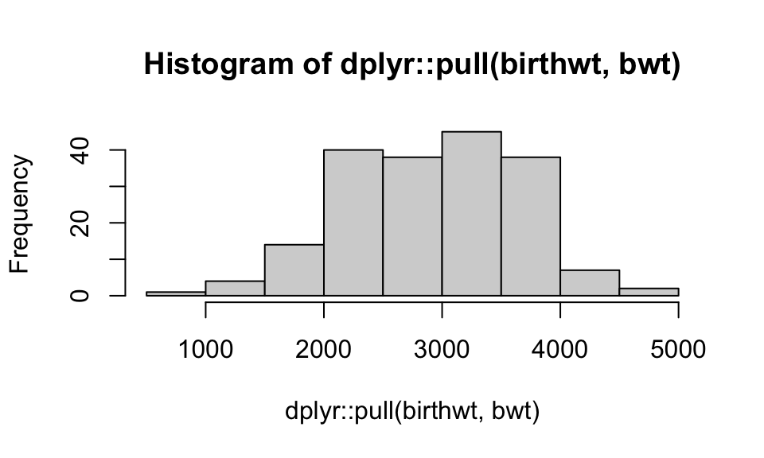

```r
birthwt |> dplyr::pull(bwt) |> hist()
```

## Operations on groups: `group_by()`

- Use `group_by()` to divide a dataset into groups meaningful for analysis.

```r
birthwt |>
  dplyr::group_by(smoke)
```

```
# A tibble: 189 × 10
# Groups:   smoke [2]
     low   age   lwt  race smoke   ptl    ht    ui   ftv   bwt
   <int> <int> <int> <int> <int> <int> <int> <int> <int> <int>
 1     0    19   182     2     0     0     0     1     0  2523
 2     0    33   155     3     0     0     0     0     3  2551
 3     0    20   105     1     1     0     0     0     1  2557
 4     0    21   108     1     1     0     0     1     2  2594
 5     0    18   107     1     1     0     0     1     0  2600
 6     0    21   124     3     0     0     0     0     0  2622
 7     0    22   118     1     0     0     0     0     1  2637
 8     0    17   103     3     0     0     0     0     1  2637
 9     0    29   123     1     1     0     0     0     1  2663
10     0    26   113     1     1     0     0     0     0  2665
# ℹ 179 more rows
```

- Notice that the data has not changed, but the output indicates that it is “grouped by” smoke (`Groups: smoke [2]`).
  - This means subsequent operations will be performed “by smoke group”.

## `group_by()`

- Combining `group_by()` and `summarise()` to calculate group-specific summary statistics is often helpful.

```r
birthwt |>
  dplyr::group_by(smoke) |> # by smoking status
  dplyr::summarise(
    mean.bwt = mean(bwt), # mean bwt
    sd.bwt = sd(bwt)      # sd bwt
  )
```

```
# A tibble: 2 × 3
  smoke mean.bwt sd.bwt
  <int>    <dbl>  <dbl>
1     0    3056.   753.
2     1    2772.   660.
```

```r
birthwt |>
  dplyr::group_by(smoke, race) |> # by smoking status and race
  dplyr::summarise(
    mean.bwt = mean(bwt), # mean bwt
    sd.bwt = sd(bwt)      # sd bwt
  )
```

```
`summarise()` has regrouped the output.
ℹ Summaries were computed grouped by smoke and race.
ℹ Output is grouped by smoke.
ℹ Use `summarise(.groups = "drop_last")` to silence this message.
ℹ Use `summarise(.by = c(smoke, race))` for per-operation grouping
  (`?dplyr::dplyr_by`) instead.
```

```
# A tibble: 6 × 4
# Groups:   smoke [2]
  smoke  race mean.bwt sd.bwt
  <int> <int>    <dbl>  <dbl>
1     0     1    3429.   710.
2     0     2    2854.   621.
3     0     3    2816.   709.
4     1     1    2827.   626.
5     1     2    2504    637.
6     1     3    2757.   810.
```

## Resolving the `group_by` warning

- The `.by` argument is typically used for per operation grouping while `group_by()` is intended for persistent grouping.

```r
birthwt |>
  dplyr::summarise(.by = c(smoke, race), # alt to group_by
                   mean.bwt = mean(bwt), sd.bwt = sd(bwt) )
```

```
# A tibble: 6 × 4
  smoke  race mean.bwt sd.bwt
  <int> <int>    <dbl>  <dbl>
1     0     2    2854.   621.
2     0     3    2816.   709.
3     1     1    2827.   626.
4     0     1    3429.   710.
5     1     2    2504    637.
6     1     3    2757.   810.
```

```r
birthwt |>
  dplyr::group_by(smoke, race) |>
  dplyr::summarise(mean.bwt = mean(bwt), sd.bwt = sd(bwt),
                   .groups = "keep") # keep groups after computation ("drop" also possible)
```

```
# A tibble: 6 × 4
# Groups:   smoke, race [6]
  smoke  race mean.bwt sd.bwt
  <int> <int>    <dbl>  <dbl>
1     0     1    3429.   710.
2     0     2    2854.   621.
3     0     3    2816.   709.
4     1     1    2827.   626.
5     1     2    2504    637.
6     1     3    2757.   810.
```

# Appendix

## `mutate()` + `case_when()`

- `case_when()` is a vectorized version of an ifelse statement.

```r
birthwt.clean = birthwt |>
  dplyr::mutate(
    ht_chr = dplyr::case_when(
      ht == 1 ~ "Hypertension",
      ht == 0 ~ "No hypertension",
      .default = NA
    ),
    race = dplyr::case_when( # this will write over the original race var
      race == 1 ~ "White",
      race == 2 ~ "Black",
      race == 3 ~ "Other",
      .default = NA
      )
    )
birthwt.clean
```

```
# A tibble: 189 × 11
     low   age   lwt race  smoke   ptl    ht    ui   ftv   bwt ht_chr
   <int> <int> <int> <chr> <int> <int> <int> <int> <int> <int> <chr>
 1     0    19   182 Black     0     0     0     1     0  2523 No hypertension
 2     0    33   155 Other     0     0     0     0     3  2551 No hypertension
 3     0    20   105 White     1     0     0     0     1  2557 No hypertension
 4     0    21   108 White     1     0     0     1     2  2594 No hypertension
 5     0    18   107 White     1     0     0     1     0  2600 No hypertension
 6     0    21   124 Other     0     0     0     0     0  2622 No hypertension
 7     0    22   118 White     0     0     0     0     1  2637 No hypertension
 8     0    17   103 Other     0     0     0     0     1  2637 No hypertension
 9     0    29   123 White     1     0     0     0     1  2663 No hypertension
10     0    26   113 White     1     0     0     0     0  2665 No hypertension
# ℹ 179 more rows
```

- Options to consider: when to write over a variable and/or object.

## `select()` + `where()`

```r
birthwt.clean |> dplyr::select(dplyr::where(is.character)) # shorthand
```

```
# A tibble: 189 × 2
   race  ht_chr
   <chr> <chr>
 1 Black No hypertension
 2 Other No hypertension
 3 White No hypertension
 4 White No hypertension
 5 White No hypertension
 6 Other No hypertension
 7 White No hypertension
 8 Other No hypertension
 9 White No hypertension
10 White No hypertension
# ℹ 179 more rows
```

```r
birthwt.clean |> dplyr::select(dplyr::where(function(x) !is.character(x) ) ) # long form
```

```
# A tibble: 189 × 9
     low   age   lwt smoke   ptl    ht    ui   ftv   bwt
   <int> <int> <int> <int> <int> <int> <int> <int> <int>
 1     0    19   182     0     0     0     1     0  2523
 2     0    33   155     0     0     0     0     3  2551
 3     0    20   105     1     0     0     0     1  2557
 4     0    21   108     1     0     0     1     2  2594
 5     0    18   107     1     0     0     1     0  2600
 6     0    21   124     0     0     0     0     0  2622
 7     0    22   118     0     0     0     0     1  2637
 8     0    17   103     0     0     0     0     1  2637
 9     0    29   123     1     0     0     0     1  2663
10     0    26   113     1     0     0     0     0  2665
# ℹ 179 more rows
```